# Midterm 1

Akshanth Srivatsa

2023-01-31

## Instructions

Answer the following questions and complete the exercises in RMarkdown. Please embed all of your code and push your final work to your repository. Your code should be organized, clean, and run free from errors. Remember, you must remove the `#` for any included code chunks to run. Be sure to add your name to the author header above.

After the first 50 minutes, please upload your code (5 points). During the second 50 minutes, you may get help from each other- but no copy/paste. Upload the last version at the end of this time, but be sure to indicate it as final. If you finish early, you are free to leave.

Make sure to use the formatting conventions of RMarkdown to make your report neat and clean! Use the tidyverse and pipes unless otherwise indicated. This exam is worth a total of 35 points.

Please load the following libraries.

```r
library(tidyverse)
library(janitor)
```

In the midterm 1 folder there is a second folder called `data`. Inside the `data` folder, there is a .csv file called `ecs21351-sup-0003-SupplementS1.csv`. These data are from Soykan, C. U., J. Sauer, J. G. Schuetz, G. S. LeBaron, K. Dale, and G. M. Langham. 2016. Population trends for North American winter birds based on hierarchical models. Ecosphere 7(5):e01351. 10.1002/ecs2.1351.

Please load these data as a new object called `ecosphere`. In this step, I am providing the code to load the data, clean the variable names, and remove a footer that the authors used as part of the original publication.

```r
ecosphere <- read_csv("data/ecs21351-sup-0003-SupplementS1.csv", skip=2) %>%
  clean_names() %>%
  slice(1:(n() - 18)) # this removes the footer
```

Problem 1. (1 point) Let’s start with some data exploration. What are the variable names?

```r
colnames(ecosphere)
```

```
##  [1] "order"                       "family"
##  [3] "common_name"                 "scientific_name"
##  [5] "diet"                        "life_expectancy"
##  [7] "habitat"                     "urban_affiliate"
##  [9] "migratory_strategy"          "log10_mass"
## [11] "mean_eggs_per_clutch"        "mean_age_at_sexual_maturity"
## [13] "population_size"             "winter_range_area"
## [15] "range_in_cbc"                "strata"
## [17] "circles"                     "feeder_bird"
## [19] "median_trend"                "lower_95_percent_ci"
## [21] "upper_95_percent_ci"
```

Problem 2. (1 point) Use the function of your choice to summarize the data.

```r
glimpse(ecosphere)
```

```
## Rows: 551
## Columns: 21
## $ order                       <chr> "Anseriformes", "Anseriformes", "Anserifor…
## $ family                      <chr> "Anatidae", "Anatidae", "Anatidae", "Anati…
## $ common_name                 <chr> "American Black Duck", "American Wigeon", …
## $ scientific_name             <chr> "Anas rubripes", "Anas americana", "Buceph…
## $ diet                        <chr> "Vegetation", "Vegetation", "Invertebrates…
## $ life_expectancy             <chr> "Long", "Middle", "Middle", "Long", "Middl…
## $ habitat                     <chr> "Wetland", "Wetland", "Wetland", "Wetland"…
## $ urban_affiliate             <chr> "No", "No", "No", "No", "No", "No", "No", …
## $ migratory_strategy          <chr> "Short", "Short", "Moderate", "Moderate", …
## $ log10_mass                  <dbl> 3.09, 2.88, 2.96, 3.11, 3.02, 2.88, 2.56, …
## $ mean_eggs_per_clutch        <dbl> 9.0, 7.5, 10.5, 3.5, 9.5, 13.5, 10.0, 8.5,…
## $ mean_age_at_sexual_maturity <dbl> 1.0, 1.0, 3.0, 2.5, 2.0, 1.0, 0.6, 2.0, 1.…
## $ population_size             <dbl> NA, NA, NA, NA, NA, NA, NA, NA, NA, NA, NA…
## $ winter_range_area           <dbl> 3212473, 7145842, 1812841, 360134, 854350,…
## $ range_in_cbc                <dbl> 99.1, 61.7, 69.8, 53.7, 5.3, 0.5, 17.9, 72…
## $ strata                      <dbl> 82, 124, 37, 19, 36, 5, 26, 134, 145, 103,…
## $ circles                     <dbl> 1453, 1951, 502, 247, 470, 97, 479, 2189, …
## $ feeder_bird                 <chr> "No", "No", "No", "No", "No", "No", "No", …
## $ median_trend                <dbl> 1.014, 0.996, 1.039, 0.998, 1.004, 1.196, …
## $ lower_95_percent_ci         <dbl> 0.971, 0.964, 1.016, 0.956, 0.975, 1.152, …
## $ upper_95_percent_ci         <dbl> 1.055, 1.009, 1.104, 1.041, 1.036, 1.243, …
```

Problem 3. (2 points) How many distinct orders of birds are represented in the data?

```r
ecosphere %>%
  summarise(n_distinct(order))
```

```
## # A tibble: 1 × 1
##   `n_distinct(order)`
##                 <int>
## 1                  19
```

Problem 4. (2 points) Which habitat has the highest diversity (number of species) in the data?

```r
ecosphere %>%
 tabyl(habitat) %>%
  arrange(-n)
```

```
##    habitat   n    percent valid_percent
##   Woodland 177 0.32123412    0.32960894
##    Wetland 153 0.27767695    0.28491620
##  Shrubland  82 0.14882033    0.15270019
##    Various  45 0.08166969    0.08379888
##      Ocean  44 0.07985481    0.08193669
##  Grassland  36 0.06533575    0.06703911
##       <NA>  14 0.02540835            NA
```

Run the code below to learn about the `slice` function. Look specifically at the examples (at the bottom) for `slice_max()` and `slice_min()`. If you are still unsure, try looking up examples online (https://rpubs.com/techanswers88/dplyr-slice). Use this new function to answer question 5 below.

```r
?slice_max
```

Problem 5. (4 points) Using the `slice_max()` or `slice_min()` function described above which species has the largest and smallest winter range?

```r
ecosphere %>%
  slice_max(winter_range_area)
```

```
## # A tibble: 1 × 21
##   order     family commo…¹ scien…² diet  life_…³ habitat urban…⁴ migra…⁵ log10…⁶
##   <chr>     <chr>  <chr>   <chr>   <chr> <chr>   <chr>   <chr>   <chr>     <dbl>
## 1 Procella… Proce… Sooty … Puffin… Vert… Long    Ocean   No      Long        2.9
## # … with 11 more variables: mean_eggs_per_clutch <dbl>,
## #   mean_age_at_sexual_maturity <dbl>, population_size <dbl>,
## #   winter_range_area <dbl>, range_in_cbc <dbl>, strata <dbl>, circles <dbl>,
## #   feeder_bird <chr>, median_trend <dbl>, lower_95_percent_ci <dbl>,
## #   upper_95_percent_ci <dbl>, and abbreviated variable names ¹common_name,
## #   ²scientific_name, ³life_expectancy, ⁴urban_affiliate, ⁵migratory_strategy,
## #   ⁶log10_mass
```

```r
ecosphere %>%
slice_min(winter_range_area)
```

```
## # A tibble: 1 × 21
##   order     family commo…¹ scien…² diet  life_…³ habitat urban…⁴ migra…⁵ log10…⁶
##   <chr>     <chr>  <chr>   <chr>   <chr> <chr>   <chr>   <chr>   <chr>     <dbl>
## 1 Passerif… Alaud… Skylark Alauda… Seed  Short   Grassl… No      Reside…    1.57
## # … with 11 more variables: mean_eggs_per_clutch <dbl>,
## #   mean_age_at_sexual_maturity <dbl>, population_size <dbl>,
## #   winter_range_area <dbl>, range_in_cbc <dbl>, strata <dbl>, circles <dbl>,
## #   feeder_bird <chr>, median_trend <dbl>, lower_95_percent_ci <dbl>,
## #   upper_95_percent_ci <dbl>, and abbreviated variable names ¹common_name,
## #   ²scientific_name, ³life_expectancy, ⁴urban_affiliate, ⁵migratory_strategy,
## #   ⁶log10_mass
```

Problem 6. (2 points) The family Anatidae includes ducks, geese, and swans. Make a new object `ducks` that only includes species in the family Anatidae. Restrict this new dataframe to include all variables except order and family.

```r
ducks<- ecosphere %>%
        filter(family=="Anatidae")  %>%
        select(-order, -family)
```

Problem 7. (2 points) We might assume that all ducks live in wetland habitat. Is this true for the ducks in these data? If there are exceptions, list the species below.

```r
ducks %>%
  tabyl(habitat)
```

```
##  habitat  n    percent
##    Ocean  1 0.02272727
##  Wetland 43 0.97727273
```

No, there are duck that are not from the wet lands

```r
ducks %>%
  filter(habitat!="Wetland") %>%
  select(common_name, scientific_name)
```

```
## # A tibble: 1 × 2
##   common_name  scientific_name
##   <chr>        <chr>
## 1 Common Eider Somateria mollissima
```

Problem 8. (4 points) In ducks, how is mean body mass associated with migratory strategy? Do the ducks that migrate long distances have high or low average body mass?

```r
ducks %>%
  group_by(migratory_strategy) %>%
  summarise(mean=mean(log10_mass, na.rm=T))
```

```
## # A tibble: 5 × 2
##   migratory_strategy  mean
##   <chr>              <dbl>
## 1 Long                2.87
## 2 Moderate            3.11
## 3 Resident            4.03
## 4 Short               2.98
## 5 Withdrawal          2.92
```

Problem 9. (2 points) Accipitridae is the family that includes eagles, hawks, kites, and osprey. First, make a new object `eagles` that only includes species in the family Accipitridae. Next, restrict these data to only include the variables common_name, scientific_name, and population_size.

```r
eagles<- ecosphere %>%
          filter(family=="Accipitridae") %>%
          select(common_name, scientific_name, population_size)
```

Problem 10. (4 points) In the eagles data, any species with a population size less than 250,000 individuals is threatened. Make a new column `conservation_status` that shows whether or not a species is threatened.

```r
eagles %>%
  mutate(conservation_status=population_size<250000)
```

```
## # A tibble: 20 × 4
##    common_name         scientific_name          population_size conservation_s…¹
##    <chr>               <chr>                              <dbl> <lgl>
##  1 Bald Eagle          Haliaeetus leucocephalus              NA NA
##  2 Broad-winged Hawk   Buteo platypterus                1700000 FALSE
##  3 Cooper's Hawk       Accipiter cooperii                700000 FALSE
##  4 Ferruginous Hawk    Buteo regalis                      80000 TRUE
##  5 Golden Eagle        Aquila chrysaetos                 130000 TRUE
##  6 Gray Hawk           Buteo nitidus                         NA NA
##  7 Harris's Hawk       Parabuteo unicinctus               50000 TRUE
##  8 Hook-billed Kite    Chondrohierax uncinatus               NA NA
##  9 Northern Goshawk    Accipiter gentilis                200000 TRUE
## 10 Northern Harrier    Circus cyaneus                    700000 FALSE
## 11 Red-shouldered Hawk Buteo lineatus                   1100000 FALSE
## 12 Red-tailed Hawk     Buteo jamaicensis                2000000 FALSE
## 13 Rough-legged Hawk   Buteo lagopus                     300000 FALSE
## 14 Sharp-shinned Hawk  Accipiter striatus                500000 FALSE
## 15 Short-tailed Hawk   Buteo brachyurus                      NA NA
## 16 Snail Kite          Rostrhamus sociabilis                 NA NA
## 17 Swainson's Hawk     Buteo swainsoni                   540000 FALSE
## 18 White-tailed Hawk   Buteo albicaudatus                    NA NA
## 19 White-tailed Kite   Elanus leucurus                       NA NA
## 20 Zone-tailed Hawk    Buteo albonotatus                     NA NA
## # … with abbreviated variable name ¹conservation_status
```

```r
?mutate_if
```

Problem 11. (2 points) Consider the results from questions 9 and 10. Are there any species for which their threatened status needs further study? How do you know?

Yes, if there is no population size, that means we cannot determine whether the status needs study or not. In this case, if there is no observed value, then we can’t tell if its threatened.

```r
eagles %>%
  filter(is.na(population_size))
```

```
## # A tibble: 8 × 3
##   common_name       scientific_name          population_size
##   <chr>             <chr>                              <dbl>
## 1 Bald Eagle        Haliaeetus leucocephalus              NA
## 2 Gray Hawk         Buteo nitidus                         NA
## 3 Hook-billed Kite  Chondrohierax uncinatus               NA
## 4 Short-tailed Hawk Buteo brachyurus                      NA
## 5 Snail Kite        Rostrhamus sociabilis                 NA
## 6 White-tailed Hawk Buteo albicaudatus                    NA
## 7 White-tailed Kite Elanus leucurus                       NA
## 8 Zone-tailed Hawk  Buteo albonotatus                     NA
```

Problem 12. (4 points) Use the `ecosphere` data to perform one exploratory analysis of your choice. The analysis must have a minimum of three lines and two functions. You must also clearly state the question you are attempting to answer.

Amongst the families available, is there a Strong relationship between eggs per clutch and winter range area?

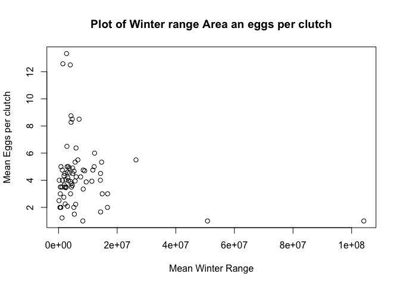

```r
family_relationship<-ecosphere %>%
      group_by(family) %>%
      summarise(mean_of_family_eggs_per_clutch=mean(mean_eggs_per_clutch), mean_of_family_winter_range_area=mean(winter_range_area)) %>%
      arrange(mean_of_family_winter_range_area)


plot(x=family_relationship$mean_of_family_winter_range_area,y = family_relationship$mean_of_family_eggs_per_clutch,
xlab = "Mean Winter Range",
     ylab = "Mean Eggs per clutch",
     main = "Plot of Winter range Area an eggs per clutch")
```

Please provide the names of the students you have worked with with during the exam:

```r
#Gautam Ponugubati
#Kyle de Mariano
```

Please be 100% sure your exam is saved, knitted, and pushed to your github repository. No need to submit a link on canvas, we will find your exam in your repository.